# Statistik och dataanalys I, 15 hp

Inlämningsuppgift 2, 1.5 hp

Authors

Namn Minhui Zhong

Namn Johanna Selö

Namn Anni Tideström

Publicerad

November 9, 2023

**Inlämning**

Inlämningsuppgiften ska lämnas in i form av ett html dokument genererat av det här Quarto-dokumentet. Öppna upp code chunks under de uppgifter de behövs.

**Kontrollera noga att du inte har några felmeddelande och att dokumentet kompileras utan problem**. Använd tydliga figurer och namnge axlarna med tydliga variabelnamn. Glöm inte att skriva era namn ovanför istället för Namn 1, Namn 2 och Namn 3.

**Matematiska symboler i rapporten**

Om en formel ska anges så är det ok att skriva det i vanlig text (markdown), typ

xbar +- t(0.025,n-1)*s/sqrt(n),

Vill man vara lite extra fancy kan man ge sig på att skriva matematik med LaTeX genom att använda dubbla dollar-tecken:

$\bar x \pm t_{0.025,n-1}\frac{s}{\sqrt n}$.

LaTeX är fint, men lite krångligt att lära sig hur man ska skriva.

Läs in dina paket här:

och definiera vår dataframe `df` med datamaterialet:

```r
df = electricitycost
head(df)
```

```
  cost rooms people income onlysecondary waterheat cookel poolfilt airrev
1  545     7      4  29900             0         0      1        0      1
2  389     7      2  11700             0         0      1        0      0
3  390     8      2  16900             0         0      0        0      0
4  268     7      2   9750             1         0      1        0      1
5  543     6      2  24700             1         0      0        0      1
6  278     6      3   8450             1         0      0        0      0
  aircond microwave dish dryer
1       1         0    0     0
2       0         1    1     0
3       1         0    0     0
4       1         0    0     1
5       1         1    0     1
6       0         0    0     1
```

## 1. Poisson-modell för antal personer i hushållet

#### 💪 Uppgift 1.1

```r
extrapeople = df$people - 1
mu = mean(extrapeople)
mu
```

```
[1] 1.646067
```

#### 💪 Uppgift 1.2

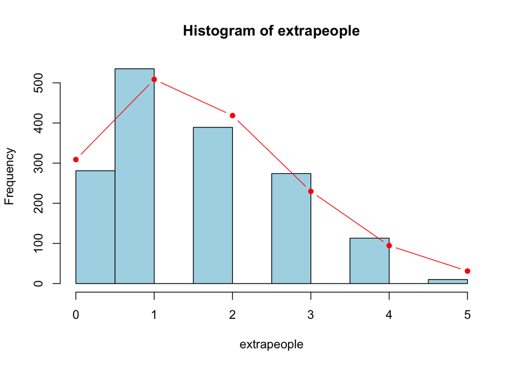

```r
# Fråga detta
lambda <- mu  # skattade parameter
x_values <- 0:max(extrapeople)
poisson_probs <- dpois(x_values, lambda)

lines(x_values,poisson_probs*sum(hist(extrapeople,main="Histogram of extrapeople", xlab="extrapeople", ylab="Frequency", col="lightblue")$counts),typ="b",pch=16,col="red")
```

#### 💪 Uppgift 1.3

Sannolikheten för ett hushåll med fler än 4 personer är ca 2.63%

```r
lambda= 1.646067
lessThan5=ppois(4, lambda)
probLess5=lessThan5
1-probLess5 #sannolikheten för ett hushåll med fler än 4 personer
```

```
[1] 0.02631036
```

#### 💪 Uppgift 1.4

Eftersom väntevärdet och variansen skiljer sig åt är antagligen inte Poissonfördelningen det bästa alternativet frör datan.

```r
# Beräkna väntevärdet (medelvärdet) för extrapeople
mean <- mean(extrapeople)
mean
```

```
[1] 1.646067
```

```r
# Beräkna variansen för extrapeople
variansen <- var(extrapeople)
variansen
```

```
[1] 1.420562
```

## 2. (log)-normalmodell för elkostnad

#### 💪 Uppgift 2.1

```r
logcost = log(df$cost) #Definera variabeln df$cost till logcost

m=mean(logcost)

s=sd(logcost)
```

#### 💪 Uppgift 2.2

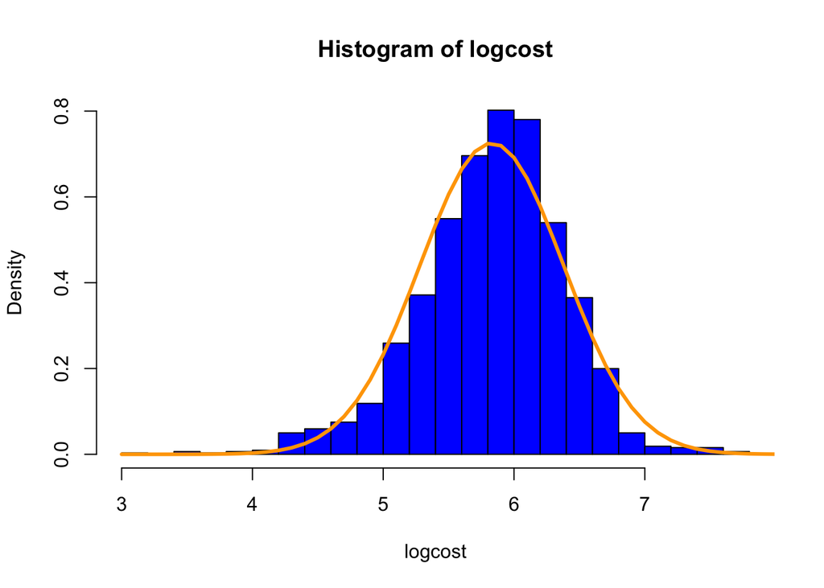

```r
hist(logcost, col="blue",breaks = 20,freq = FALSE,main="Histogram of logcost")
mean=5.83
s=0.55
x_grid = seq(3, 8, by = 0.1)
x_sample = dnorm(logcost, mean = m, sd = s)
dens_norm = dnorm(x_grid, mean = m, sd = s)  # density (x) for all values in vector xgrid
lines(x_grid, dens_norm, lwd = 3, col = "orange")
```

#### 💪 Uppgift 2.3

Vi ser att 99%-kvantilen från den skattade sannolikhetsmodellen blir lite större.

```r
#Beräkna 99%-kvantilen av logcost från data
quantile_data <- quantile(log(df$cost),probs=0.99)
quantile_data
```

```
     99%
7.071462
```

```r
#Beräkna 99%-kvantilen från den skttade normalmodellen
quantile_model <- qnorm(0.99,mean(logcost),sd(logcost))
quantile_model
```

```
[1] 7.113892
```

#### 💪 Uppgift 2.4

Gör ett 95%-igt konfidensintervall för m i modellen för logcost från Uppgift 2.1, både genom att använda formelsamlingen och genom att använda en funktion i R. Tolka intervallet.

Svar: 5.829855 ± z0.05/2 · SE(x-bar) (0.5519541 / roten ur 1601)

5.829855 ± 1.96 · 0.01379 = 5.829855 ± 0.027 = 5.803; 5.857)

Vi kan med 95% konfidens säga att om vi skulle upprepa studien väldigt många gånger med samma antal n så skulle vi vid 95% av gångerna fånga det sanna väntevärdet i populationen i våra intervall.

```r
t.test(logcost,conf.level = 0.95)
```

```
    One Sample t-test

data:  logcost
t = 422.75, df = 1601, p-value < 2.2e-16
alternative hypothesis: true mean is not equal to 0
95 percent confidence interval:
 5.802806 5.856904
sample estimates:
mean of x
 5.829855
```

#### 💪 Uppgift 2.5

H0:logcost =350 dollar

H1:logcost< 350 dollar

Ensidigt hypotestest

Teststatistika: 5.829855 - 5.857933 / (s / roten ur n) = -0.028078 / (0.551941/(roten ur 1602) =

-0.028078 / 0.01379023629 = -2.036078237 ≈ -2.04

tcrit = t0.05/2,1602-1 (avänder 1000) = 1.962 7obs = -2.04 symmetri = 2.04. Vårt observerade värde är större än det kritiska så vi kan förkasta nollhypotesen på 5% signifikansnivå.

```r
#Nollhypotesvärde
value <- log(350)

# Beräkna t-värdet med formelsamling
t_value <- (m - value) / (s / sqrt(1601))
t_value
```

```
[1] -2.042696
```

```r
#R räkningen
t.test(logcost,mu=log(350),alternative = "less")
```

```
    One Sample t-test

data:  logcost
t = -2.0361, df = 1601, p-value = 0.02095
alternative hypothesis: true mean is less than 5.857933
95 percent confidence interval:
     -Inf 5.852551
sample estimates:
mean of x
 5.829855
```

#### 💪 Uppgift 2.6

Vi kan inte förkasta nollhypotesen på 1% signifikansnivå pga p_ värdet är större än 0.01.

```r
pnorm(-2.0361)
```

```
[1] 0.02087016
```

#### 💪 Uppgift 2.7

Enligt vår dataset har vi n > 30 så kan medelvärdet antas vara approx. normalfördelat. I Centrala gränsvärdessatsen (CGS) säger att om man adderar ett stort antal oberoende variabler från en godtycklig fördelning blir summan ( eller medelvärdet) normalfördelat.

#### 💪 Uppgift 2.8

H0: mu0 = mu1

HA: mu0 ≠ mu1

Med aircondition: 1: mean: 5,913 sd: 0.525 n: 1084

Utan aircondition: 0: mean: 5.656, sd: 0.567 n: 518

Teststatistika: 5.913 - 5.656 - 0 / roten ur (0.525^2 / 1084 + 0.567^2/518) = 0.257/0.0296 = 8.68

```r
new_df <-split(df, df$aircond)
dfaircon0<-new_df[["0"]]#plocka fram värdet från variabeln
dfaircon1<-new_df[["1"]]
logcost_0 = log(dfaircon0$cost)
logcost_1 = log(dfaircon1$cost)


m0 = mean(logcost_0, df=dfaircon0)
m1 = mean(logcost_1, df=dfaircon1)

t.test(logcost_1,logcost_0)
```

```
    Welch Two Sample t-test

data:  logcost_1 and logcost_0
t = 8.6659, df = 951.14, p-value < 2.2e-16
alternative hypothesis: true difference in means is not equal to 0
95 percent confidence interval:
 0.1982845 0.3143814
sample estimates:
mean of x mean of y
 5.912739  5.656406
```

## 3. Enkel och multipel linjär regression

#### 💪 Uppgift 3.1

Den skattningen av intercept är ca 2.46 och lutningskoefficient är ca 0.35 och skattning av $\sigma_{\varepsilon}$ är ca 0.49. Interceptet är värdet som y antar när x värdet är 0. Logcost är alltså 2.46 när logincome är 0. Lutningen 0.35 är så mycket som logcost ökar med varje värdeökning för x(logincome).

```r
df$logincome = log(df$income)
head(df)
```

```
  cost rooms people income onlysecondary waterheat cookel poolfilt airrev
1  545     7      4  29900             0         0      1        0      1
2  389     7      2  11700             0         0      1        0      0
3  390     8      2  16900             0         0      0        0      0
4  268     7      2   9750             1         0      1        0      1
5  543     6      2  24700             1         0      0        0      1
6  278     6      3   8450             1         0      0        0      0
  aircond microwave dish dryer logincome
1       1         0    0     0 10.305614
2       0         1    1     0  9.367344
3       1         0    0     0  9.735069
4       1         0    0     1  9.185023
5       1         1    0     1 10.114559
6       0         0    0     1  9.041922
```

```r
model1 = lm(logcost ~ logincome, data = df)
summary(model1)
```

```
Call:
lm(formula = logcost ~ logincome, data = df)

Residuals:
     Min       1Q   Median       3Q      Max
-2.24889 -0.29136  0.02225  0.31546  1.79446

Coefficients:
            Estimate Std. Error t value Pr(>|t|)
(Intercept)  2.46486    0.16350   15.08   <2e-16 ***
logincome    0.34770    0.01685   20.64   <2e-16 ***
---
Signif. codes:  0 '***' 0.001 '**' 0.01 '*' 0.05 '.' 0.1 ' ' 1

Residual standard error: 0.4907 on 1600 degrees of freedom
Multiple R-squared:  0.2103,    Adjusted R-squared:  0.2098
F-statistic:   426 on 1 and 1600 DF,  p-value: < 2.2e-16
```

#### 💪 Uppgift 3.2

99% konfidensintervall för b1:

0.34770 ± t0.01/2,1602-2 · 0.01685 =

0.34770 ± 2.581 · 0.01685 =

0.34770±0.0435 =

Konfidensintervall: 0.3042 - 0.3912

```r
confint(model1)
```

```
                2.5 %    97.5 %
(Intercept) 2.1441705 2.7855549
logincome   0.3146597 0.3807472
```

#### 💪 Uppgift 3.3

H0 = 0

HA ≠ 0

Teststatiska: 0.3477 / 0.01685 = 20.635

tcrit = t0.01/2,1602-2 (använder 1000) = 2.581

tobs > tcrit, därför förkastar vi nollhypotesen. Logincome är en signifikant förklarandevariabel på 1% signifikansnivå.

```r
model1 <- lm(logcost ~ logincome, data = df)
reg_summary(model1)
```

```
Analysis of variance - ANOVA
------------------------------------------------
        df     SS        MS      F     Pr(>F)
Regr     1 102.55 102.55445 425.98 4.2131e-84
Error 1600 385.20   0.24075
Total 1601 487.75

Measures of model fit
------------------------------------------------
Root MSE       R2   R2-adj
 0.49066  0.21026  0.20977

Parameter estimates
------------------------------------------------
            Estimate Std. Error t value   Pr(>|t|)
(Intercept)   2.4649   0.163498  15.076 4.0027e-48
logincome     0.3477   0.016847  20.639 4.2131e-84
```

```r
# H0: beta_tv = 0, Ha: beta_tv != 0
t_teststatistikan <- (0.34770-0)/0.01685
t_teststatistikan
```

```
[1] 20.63501
```

```r
n = nrow(df)
qt(0.995,n-2)
```

```
[1] 2.578906
```

```r
t_teststatistikan > qt(0.995,n-2) # if TRUE -> reject H0: Beta1 = 0
```

```
[1] TRUE
```

#### 💪 Uppgift 3.4

```r
model1 = lm(logcost ~ logincome, data = df)
# Anpassat värde/prediktion för Sverige:
predict(model1, newdata = data.frame(logincome = 11),interval="prediction")
```

```
       fit      lwr      upr
1 6.289601 5.325905 7.253296
```

#### 💪 Uppgift 3.5

Vi tolkar b1 är 0.18 då ökar logcost med 0.18 för varje enhetsökning i logincome, När dummyvariabeln aircond är satt till 1, ökar logcost med ca 0.13.

```r
df$logrooms=log(df$rooms)
df$logpeople=log(df$people)

model2 <- lm(logcost ~ logincome + logrooms + logpeople + onlysecondary + poolfilt + aircond, data = df)
summary(model2)
```

```
Call:
lm(formula = logcost ~ logincome + logrooms + logpeople + onlysecondary +
    poolfilt + aircond, data = df)

Residuals:
    Min      1Q  Median      3Q     Max
-2.1166 -0.2582  0.0040  0.2799  1.6112

Coefficients:
              Estimate Std. Error t value Pr(>|t|)
(Intercept)    2.70092    0.17220  15.684  < 2e-16 ***
logincome      0.17874    0.01750  10.216  < 2e-16 ***
logrooms       0.55819    0.06213   8.984  < 2e-16 ***
logpeople      0.30927    0.02597  11.909  < 2e-16 ***
onlysecondary -0.04647    0.02263  -2.053  0.04023 *
poolfilt       0.12453    0.04063   3.065  0.00221 **
aircond        0.13048    0.02407   5.421 6.84e-08 ***
---
Signif. codes:  0 '***' 0.001 '**' 0.01 '*' 0.05 '.' 0.1 ' ' 1

Residual standard error: 0.4397 on 1595 degrees of freedom
Multiple R-squared:  0.3677,    Adjusted R-squared:  0.3653
F-statistic: 154.6 on 6 and 1595 DF,  p-value: < 2.2e-16
```

#### 💪 Uppgift 3.6

Enligt summary av model2 fick vi fram att förklarande variabler onlysecondary är signifikant på en 5%-igt signifikansnivån och förklarande variabler poolfilt är på en 1%-igt signifikansnivån.

#### 💪 Uppgift 3.7

```r
favstats(df$logincome) # median 9.74
```

```
     min       Q1   median       Q3     max     mean        sd    n missing
 7.17012 9.041922 9.735069 10.21464 11.0021 9.677765 0.7279015 1602       0
```

```r
favstats(df$logrooms) # median 1.95
```

```
      min       Q1  median       Q3      max     mean        sd    n missing
 1.386294 1.791759 1.94591 2.079442 2.302585 1.890919 0.2041145 1602       0
```

```r
favstats(df$logpeople) # median 0.69
```

```
 min        Q1    median       Q3      max      mean        sd    n missing
   0 0.6931472 0.6931472 1.098612 1.791759 0.8600641 0.4953961 1602       0
```

```r
model2 = lm(logcost ~ logincome + logrooms + logpeople + onlysecondary + poolfilt + aircond, data = df)

# Prediktionsintervall - sda123
predict(model2, newdata = data.frame(logincome=9.74,logrooms=1.95,logpeople=0.69,onlysecondary=0,poolfilt=0,aircond=0),interval="prediction",level=0.9)
```

```
      fit     lwr     upr
1 5.74368 5.01897 6.46839
```